# Plot Spectral Signatures Derived from Hyperspectral Remote Sensing Data in HDF5 Format in R

## Learning Objectives

After completing this tutorial, you will be able to:

- Extract and plot a single spectral signature from an HDF5 file.
- Work with groups and datasets within an HDF5 file.

## Things You’ll Need To Complete This Tutorial

To complete this tutorial you will need the most current version of R and, preferably, RStudio loaded on your computer.

### R Libraries to Install:

- **rhdf5**: `install.packages("BiocManager")`, `BiocManager::install("rhdf5")`
- **plyr**: `install.packages('plyr')`
- **ggplot2**: `install.packages('ggplot2')`

[More on Packages in R - Adapted from Software Carpentry.](https://www.neonscience.org/packages-in-r)

### [Download NEON Teaching Data Subset: Imaging Spectrometer Data - HDF5](https://ndownloader.figshare.com/files/21754221)

These hyperspectral remote sensing data provide information on the [National Ecological Observatory Network’s](https://www.neonscience.org/) [San Joaquin Exerimental Range field site](https://www.neonscience.org/field-sites/field-sites-map/SJER) in March of 2019. The data were collected over the San Joaquin field site located in California (Domain 17) and processed at NEON headquarters. This data subset is derived from the mosaic tile named NEON_D17_SJER_DP3_257000_4112000_reflectance.h5. The entire dataset can be accessed by request from the [NEON Data Portal](http://data.neonscience.org).

[Download Dataset](https://ndownloader.figshare.com/files/21754221)

**Remember** that the example dataset linked here only has 1 out of every 4 bands included in a full NEON hyperspectral dataset (this substantially reduces the file size!). When we refer to bands in this tutorial, we will note the band numbers for this example dataset, which are different from NEON production data. To convert a band number (b) from this example data subset to the equivalent band in a full NEON hyperspectral file (b’), use the following equation: b’ = 1+4*(b-1).

**Set Working Directory:** This lesson assumes that you have set your working directory to the location of the downloaded and unzipped data subsets.

[An overview of setting the working directory in R can be found here.](https://www.neonscience.org/set-working-directory-r)

**R Script & Challenge Code:** NEON data lessons often contain challenges that reinforce learned skills. If available, the code for challenge solutions is found in the downloadable R script of the entire lesson, available in the footer of each lesson page.

### Recommended Skills

For this tutorial, you should be comfortable reading data from a HDF5 file and have a general familiarity with hyperspectral data. If you aren’t familiar with these steps already, we highly recommend you work through the [*Introduction to Working with Hyperspectral Data in HDF5 Format in R* tutorial](https://www.neonscience.org/hsi-hdf5-r) before moving on to this tutorial.

Everything on our planet reflects electromagnetic radiation from the Sun, and different types of land cover often have dramatically different refelectance properties across the spectrum. One of the most powerful aspects of the NEON Imaging Spectrometer (NIS, or hyperspectral sensor) is that it can accurately measure these reflectance properties at a very high spectral resolution. When you plot the reflectance values across the observed spectrum, you will see that different land cover types (vegetation, pavement, bare soils, etc.) have distinct patterns in their reflectance values, a property that we call the ‘spectral signature’ of a particular land cover class.

In this tutorial, we will extract the reflectance values for all bands of a single pixel to plot a spectral signature for that pixel. In order to do this, we need to pair the reflectance values for that pixel with the wavelength values of the bands that are represented in those measurements. We will also need to adjust the reflectance values by the scaling factor that is saved as an ‘attribute’ in the HDF5 file. First, let’s start by defining the working directory and reading in the example dataset.

```r
# Call required packages
library(rhdf5)
library(plyr)
library(ggplot2)

# set working directory to ensure R can find the file we wish to import and where
# we want to save our files. Be sure to move the download into your working directory!
wd <- "~/data/" #This will depend on your local environment
setwd(wd)
```

Now, we can look at the contents of the H5 file as follows:

```r
# Define the file name to be opened
f <- paste0(wd,"NEON_hyperspectral_tutorial_example_subset.h5")
# look at the HDF5 file structure
h5ls(f,all=T)
```

```
##                                           group                     name
## 0                                             /                     SJER
## 1                                         /SJER              Reflectance
## 2                             /SJER/Reflectance                 Metadata
## 3                    /SJER/Reflectance/Metadata        Coordinate_System
## 4  /SJER/Reflectance/Metadata/Coordinate_System Coordinate_System_String
## 5  /SJER/Reflectance/Metadata/Coordinate_System                EPSG Code
## 6  /SJER/Reflectance/Metadata/Coordinate_System                 Map_Info
## 7  /SJER/Reflectance/Metadata/Coordinate_System                    Proj4
## 8                    /SJER/Reflectance/Metadata            Spectral_Data
## 9      /SJER/Reflectance/Metadata/Spectral_Data               Wavelength
## 10                            /SJER/Reflectance         Reflectance_Data
##            ltype cset       otype num_attrs  dclass          dtype  stype rank
## 0  H5L_TYPE_HARD    0   H5I_GROUP         0                                  0
## 1  H5L_TYPE_HARD    0   H5I_GROUP         5                                  0
```

[output cut: 21 more lines]

## Read Wavelength Values

Next, let’s read in the wavelength center associated with each band in the HDF5 file. We will later match these with the reflectance values and show both in our final spectral signature plot.

```r
# read in the wavelength information from the HDF5 file
wavelengths <- h5read(f,"/SJER/Reflectance/Metadata/Spectral_Data/Wavelength")
```

## Extract Z-dimension data slice

Next, we will extract all reflectance values for one pixel. This makes up the spectral signature or profile of the pixel. To do that, we’ll use the `h5read()` function. Here we pick an arbitrary pixel at `(100,35)`, and use the `NULL` value to select *all* bands from that location.

```r
# extract all bands from a single pixel
aPixel <- h5read(f,"/SJER/Reflectance/Reflectance_Data",index=list(NULL,100,35))

# The line above generates a vector of reflectance values.
# Next, we reshape the data and turn them into a dataframe
b <- adply(aPixel,c(1))

# create clean data frame
aPixeldf <- b[2]

# add wavelength data to matrix
aPixeldf$Wavelength <- wavelengths

head(aPixeldf)
```

```
##    V1 Wavelength
## 1 720   381.5437
## 2 337   401.5756
## 3 336   421.6075
## 4 399   441.6394
## 5 406   461.6713
## 6 426   481.7032
```

## Scale Factor

Then, we can pull the spatial attributes that we’ll need to adjust the reflectance values. Often, large raster data contain floating point (values with decimals) information. However, floating point data consume more space (yield a larger file size) compared to integer values. Thus, to keep the file sizes smaller, the data will be scaled by a factor of 10, 100, 10000, etc. This `scale factor` will be noted in the data attributes.

```r
# grab scale factor from the Reflectance attributes
reflectanceAttr <- h5readAttributes(f,"/SJER/Reflectance/Reflectance_Data" )

scaleFact <- reflectanceAttr$Scale_Factor

# add scaled data column to DF
aPixeldf$scaled <- (aPixeldf$V1/as.vector(scaleFact))

# make nice column names
names(aPixeldf) <- c('Reflectance','Wavelength','ScaledReflectance')
head(aPixeldf)
```

```
##   Reflectance Wavelength ScaledReflectance
## 1         720   381.5437            0.0720
## 2         337   401.5756            0.0337
## 3         336   421.6075            0.0336
## 4         399   441.6394            0.0399
## 5         406   461.6713            0.0406
## 6         426   481.7032            0.0426
```

## Plot Spectral Signature

Now we’re ready to plot our spectral signature!

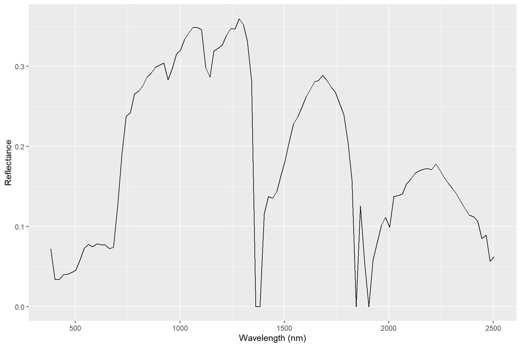

Spectral signature plot with wavelength in nanometers on the x-axis and reflectance on the y-axis.

```r
ggplot(data=aPixeldf)+
   geom_line(aes(x=Wavelength, y=ScaledReflectance))+
   xlab("Wavelength (nm)")+
   ylab("Reflectance")
```